# Dance, meet Data

Prior to attending the University of Washington and studying computer science/data science, I worked as the Marketing Director of City Opera Ballet. During my time there I often struggled to glean valuable insights from the ticket sales reports generated by BrownPaperTickets. Once I started my studies at UW I thought it would be a fun challenge to take another look at this data.

The companies ticket sales reports were in a series of excel files by show. Upon looking at the data, I found several key issues that needed to be addressed in order to get anything useful from these reports.

```python
# imports
import numpy as np
import pandas as pd

from IPython.display import display, Image

%matplotlib inline
```

After importing a few useful libraries, I needed to read each file into a Pandas DataFrame and put these DataFrames into a dictionary.

```python
# list of files to be processed
files = ['CosifanTutte.xlsx','Firebird2014.xlsx','Firebird2017.xlsx','Giselle.xlsx','Messiah2012.xlsx','Messiah2015.xlsx','Nutcracker2009.xlsx','Nutcracker2010.xlsx','Nutcracker2014.xlsx','OBitC2015.xlsx','OBitC2016.xlsx','RomeoandJuliet.xlsx','SleepingBeauty.xlsx','Snowman2008.xlsx','Snowman2016.xlsx']
# dataset in which to aggregate data from files
data = {}
for f in files:
    # read in each file in the list
    d = pd.read_excel("COB/{0}".format(f), header=5, index_col=None)
    # add each file as a k,v pair in a larger dataset
    data[f.replace(".xlsx", "")] = d
```

# Cleanup Time

Now onto a bit of cleaning. To begin with, the excel files are filled with empty rows, and header/title rows that are of little use. There are also multiple duplicate header rows in each file associated with different delivery methods. These all needed to be dropped from the DataFrames.

I also chose to drop all rows with a price of $0 (complementary tickets) as none of these tickets had customer data associated with them.

```python
for k,v in data.items():
    # drop any lines with fewer than 3 values
    v.dropna(axis=0, how='any', thresh=3, inplace=True)
    # drop any duplicate lines
    v.drop_duplicates(keep=False, inplace=True)
    # drop all lines where Price==0 (complementary tickets)
    v.query('Price != 0', inplace=True)
    # reset the index column
    v.index = np.arange(1, len(v)+1)
```

These DataFrames also contained several columns of data that wasn't useful for the analysis we were interested in. So I dropped those and renamed the other columns with more concise/useful names.

```python
for k,v in data.items():
    # drop the columns whose data is not of use for this evaluation
    v.drop(columns=['Ticket ID','Order Date','Event End Date','Company/Org','Shipping L Name','Shipping F Name','Shipping Address','Shipping Address Line 2','Shipping Country','Phone','Email','Card Number','Barcode','Box Office User','Order Notes','Admitted','Member Discount Code'],inplace=True)
    # rename columns with simpler names
    v.columns = ['Event Date', 'Last Name', 'First Name', 'City', 'State', 'ZIP', 'Level', 'Price']
    v['Show'] = k
```

Another major issue that was making any useful analysis difficult was the inconsistency in the "Admission Level" across different shows. All in all I found a total of 54 separate admission levels between the shows. I condensed these down to 7 to make it easier to analyze audience demographics.

```python
for k,v in data.items():
    # simplify the multiple 'child' ticket levels
    v.replace([' Downhill Discount (Child)',' Child (age 5 and below)',' Child (age 5 and below)'],'Child',inplace=True)
    # simplify the multiple 'student/senior/miltary' ticket levels
    v.replace(['Student/Senior(+62) Hotel Discount','St/Sr 62+/Mil','Student/Senior(+62)','Student/Senior','student/senior','Student/Senior','Student/Seniors','Student/Senior/Military'],'Student/Senior/Military',inplace=True)
    # simplify the multiple 'student' ticket levels
    v.replace(['Students',' Downhill Discount (Student)',' Student (with student card)',' Student (with student card)'],'Student',inplace=True)
    # simplify the multiple 'senior' ticket levels
    v.replace(['Senior','Seniors',' Downhill Discount (Senior)',' Senior (age 62+)'],'Senior',inplace=True)
    # simplify the multiple 'discount' ticket levels
    v.replace(['Under 25','Adult Hotel Discount','DISCOUNT- reduced side and upp','DISCOUNT- side and upper','Discounted Adult','VIP Hotel Discount','General - Spirit Discount','DISCOUNT- Orchestra','reduced side and upper',' Downhill Discount (Adult)','side and upper'],'Discount',inplace=True)
    # simplify the multiple 'adult' ticket levels
    v.replace(['Adult','General','Orchestra','Adult ',' Adult','Adults','Adults..Side','adult','Adults..Center'],'Adult',inplace=True)
    # simplify the multiple 'patron/VIP' ticket levels
    v.replace(['Patron','VIP seating ','DISCOUNT- VIP',' Downhill Discount (VIP)','Patron ','Patron (VIP Seating)','Preferred','Preferred ',' VIP', 'VIP Seating', 'VIP', 'Patron Seating', 'Patron Package'],'Patron/VIP',inplace=True)
```

Next was the issue of zipcodes. Most of the zipcodes in the original excel file were stored in numerical format, and so the zipcodes for cities like Bar Harbor, ME, with zipcodes 04609 had the initial 0 dropped in the excel sheet.

There were also some customers who entered there zipcode in the 9-digit format. I trimmed off the trailing 4 digits from the 9-digit zipcodes and added the leading zeroes to the zipcodes beginning in 0.

```python
for k,v in data.items():
    # cast ZIP as a string
    v['ZIP'] = v['ZIP'].astype('str', copy=False)
    # trim trailing digits of 9-digit zipcodes
    v['ZIP'] = v['ZIP'].str[:5]
    # add leading zeroes to zipcodes starting with 0 (e.g. 04609, Bar Harbor, ME)
    v['ZIP'] = v['ZIP'].apply(lambda x: '{0:0>5}'.format(x))
```

I did a bit more cleaning up of formatting for consistency across the DataFrame.

```python
for k,v in data.items():
    # clean up string formatting for remaining data
    v['Last Name'] = v['Last Name'].str.title()
    v['First Name'] = v['First Name'].str.title()
    v['City'] = v['City'].str.title()
    v['State'] = v['State'].str.upper()
```

# Visualizing the Data

Now that we have a clean dataset we can do some visualizations with the data.

We're now able to look at shows individually to see how sales compared by price...

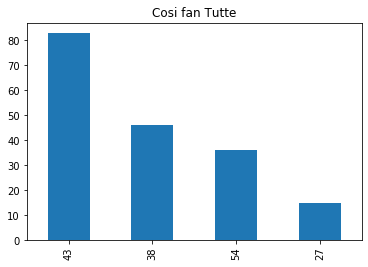

```python
pd.value_counts(data['CosifanTutte']['Price']).plot.bar(title='Cosi fan Tutte')
```

by admission level...

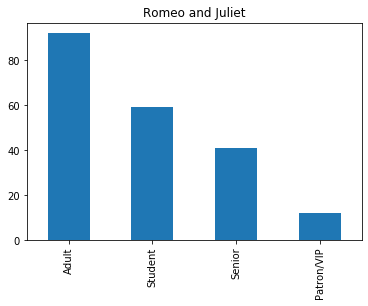

```python
pd.value_counts(data['RomeoandJuliet']['Level']).plot.bar(title='Romeo and Juliet')
```

or by zipcode...

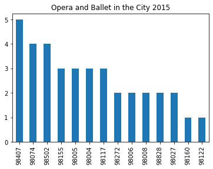

```python
pd.value_counts(data['OBitC2015']['ZIP']).plot.bar(title='Opera and Ballet in the City 2015')
```

or by performance date...

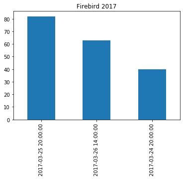

```python
pd.value_counts(data['Firebird2017']['Event Date']).plot.bar(title='Firebird 2017')
```

I was then able to use this data to construct a separate dataframe tracking the attendance and revenue for each show.

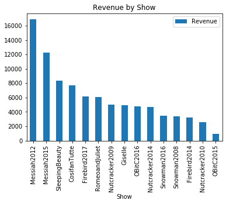

```python
master = pd.DataFrame(columns=['Show','Revenue','Attendance'])
for k,v in data.items():
    master = master.append({'Show': k, 'Revenue': v['Price'].sum(), 'Attendance': v.shape[0]},ignore_index=True)
master.sort_values(by='Revenue',ascending=False,inplace=True)
master.plot.bar(x='Show', y='Revenue',title='Revenue by Show')
```

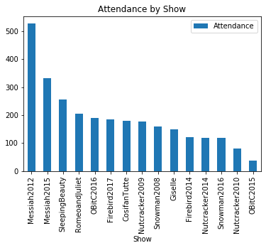

```python
master.sort_values(by='Attendance',ascending=False,inplace=True)
master.plot.bar(x='Show', y='Attendance',title='Attendance by Show')
```

The company can now use this information to inform their marketing efforts for future performances. They will also be utilizing brownpapertickets questionaire function for future performances to see where audience members heard about performances so that we can analyse that data and further improve the companies marketing efforts.